# Report Notebook

- A report on the retention and use of the moodtracker feature.
- A report on the employee emotional state and evolution per industry.
- A report on content consumption.

Since the information necessary for all the reports is shared, it was decided that all three would share the same notebook, so that they can share the same functions, variables and transformations.

1. Population Description
   1. Initial EDA
   2. Population Overview
2. Moodtracker
   1. Initial EDA
   2. First & Last Seen
   3. Daily Activity
3. Emotional State Analysis
   1. General Population
   2. Per Industry
   3. Per Company
   4. Per (Guessed) Gender
   5. Per Age Group
4. Content Consumption
5. Final Remarks

```python
# Imports
import numpy as np
import modin.pandas as pd
import gender_guesser.detector as gender
import warnings
import seaborn as sns
import matplotlib.pyplot as plt
from functools import reduce
from PsqlConn import create_psql_engine

# Setup
%matplotlib inline

# Make tables easier to see
pd.set_option('display.max_columns', None)
pd.set_option('display.expand_frame_repr', False)
pd.set_option('max_colwidth', -1)

# Suppress warnings (for better notebook readability)
warnings.filterwarnings(action='ignore')

# Apply seaborn default settings
sns.set()

# Create engine for connection with DB
engine = create_psql_engine()
```

```python
# Utility functions

# These could've been lambda functions, but the function name is used as the column name, so it's handier this way
def male_count(series:pd.Series):
    return sum(series == 'male')

def female_count(series:pd.Series):
    return sum(series == 'female')

def male_female_ratio(series:pd.Series):
    return sum(series == 'male')/sum(series == 'female')

def unknown_count(series:pd.Series):
    return sum(series == 'unknown')

def get_mode(series:pd.Series, last=True):
    """
    This function returns the mode of a series.
    If there is no clear mode value it takes either the first or last value
    """
    ind = 1 if last else 0
    mode = series.mode()
    if mode.shape[0] > 1:
        return mode[ind]
    else:
        return mode[0]

def diff_time(series:pd.Series):
    """
    Compute the time difference between consecutive timestamps in a series
    """
    datetime_series = pd.Series(pd.to_datetime(series))
    sorted_series = datetime_series.sort_values()
    return list(sorted_series.diff())

# Plotting functions
def mood_evolution(df, subset_text='All population'):
    """
    Plot a stacked barplot of the mood evolution of a given dataframe
    """
    mood_count_date = df.groupby(["trackedat_date", "mood"])["userid"].count().reset_index()

    # Subset data per mood type
    subset_list = []
    bottom_list=[]
    for i, mood_v in enumerate(mood_count_date["mood"].unique()):
        subset_list.append(mood_count_date.query("mood == @mood_v")[["trackedat_date","userid", "mood"]])
        if i !=0:
            bottom_list.append(bottom_list[i-1][["userid"]] + subset_list[i].reset_index()[["userid"]])
        else:
            bottom_list.append(subset_list[i].reset_index()[["userid"]])

    # Plot
    fig = plt.figure(figsize=(30,10))
    ax_list=[]
    for i, s in enumerate(subset_list):
        if i == 0:
            p = plt.bar(x='trackedat_date', height = "userid",
                   data=s)
            ax_list.append(p[0])
            leg_list=[s["mood"].unique()[0]]
        else:
            p = plt.bar(x='trackedat_date', height = "userid",
                        data=s,
                        bottom = bottom_list[i-1]["userid"]) # get value from previous dataframe
            ax_list.append(p[0])
            leg_list=leg_list+[s["mood"].unique()[0]]

    plt.title("Mood evolution" + f" ({subset_text})")
    plt.xlabel("Date")
    plt.ylabel("Reported cases")
    plt.tick_params('x',labelrotation=70)
    plt.legend(ax_list, leg_list)

    plt.show()


def mood_comparison(df, mood1, mood2):
    q_string = f"mood == '{mood1}' or mood == '{mood2}'"
    ex_mood = df.query(q_string).groupby(["trackedat_date", "mood"])["userid"].count().reset_index().copy()
    chart=sns.catplot(x = 'trackedat_date', y =  'userid',
               hue='mood', data=ex_mood, kind = 'bar', height = 6, aspect=4, legend=False)

    chart_l = sns.lineplot(x = 'trackedat_date', y =  'userid',data=ex_mood,
                           hue = 'mood', dashes =True, markers=True, legend=False)

    plt.setp(chart_l.lines, alpha=.3)

    chart.set(xlabel = 'Date',
             ylabel='Number of users',
             title='Number of users super-happy or angry per day')

    plt.legend(loc='best')

    plt.xticks(rotation = 70)
    plt.show()
```

## Population description

First let's take a look at our population and try to understand what's the distribution of users among companies, industries and ages.

### Initial EDA

```python
# Query to fetch a simple user table with company and industry names
pop_q = f'''
-- Get users and their company and industry
select distinct u.id as userid,
                u.name as username,
                u.age as userage,
                cm.name as companyname,
                i.name as industryname
from users u
left join companies cm
on(cast(u.companyid as text) = cm.id )
left join industries i
on(i.id = cast(u.industryid as text) )
;
'''

pop_df = pd.read_sql_query(pop_q, engine)
pop_df.head()
```

|  | userid | username | userage | companyname | industryname |
| --- | --- | --- | --- | --- | --- |
| 0 | 517a8deb-14d2-4662-8ca5-a2515bf06326 | Aurelia | 21 | Apple | Marketing |
| 1 | b3152a96-6055-44f5-87fe-4d1763129bb9 | Alisa | 25 | Pied Piper | Marketing |
| 2 | 5c185183-ee83-426b-b535-8d9ba776c731 | Chester | 36 | Twitter | Marketing |
| 3 | 4a45d028-906e-4e42-b768-7071b48bc6e4 | Zechariah | 36 | Pied Piper | Finance |
| 4 | d94ca93a-66f3-4972-a07d-c774109ba7d3 | Ramona | 29 | Twitter | Sales |

Straight away, one thing we can do to augment our data is to try to guess what is the gender of the user based on their name. We can infer that using a package such as https://pypi.org/project/gender-guesser/.

```python
# Create a detector object
genderDetector = gender.Detector()

# We guess the the genders and then check what we got
pop_df['genderguess'] = pop_df.username.apply(lambda x: genderDetector.get_gender(x))

print(f"Out of {pop_df['userid'].nunique()} users, this was the proportion of genders guessed:")
display(pop_df['genderguess'].value_counts())
```

```
Out of 2000 users, this was the proportion of genders guessed:
```

```
female           883
male             831
unknown          147
mostly_male      62
mostly_female    51
andy             26
dtype: int64
```

With this we were able to guess around 86% as definitively either male of female. Some remarks:

- The `mostly_male` and `mostly_female` labels represent 3.1% and 2.6% of the population so we are going to join them with the `male` and `female` labels for simplicity.
- The `andy` label represents names that can be either male or female. This label represents 1.3% of our population. Since this is such a low value we are going to keep it as it's own thing instead of drilling down further.
- The `unknow` label represents names that the detector was unable to guess as either gender. They are 7.35% of our population, so it's also a small subset. The total number of distinct names is 116. Since the gender is just a guess, there is no point in trying to fit the these into either of the male or female labels.

```python
# Replace the `mostly_xxx`labels with the definitive ones
gender_simpl_dict = {"mostly_male":'male',
                    "mostly_female": 'female',
                    }
pop_df["genderguess"]=pop_df["genderguess"].replace(gender_simpl_dict)

# Save categories as factor to save memory
pop_df["genderguess"]=pop_df["genderguess"].astype('category')
```

```python
# Lets check how many users we have per company, industry and company + industry
print("Number of unique users per company")
display(pop_df.groupby("companyname")["userid"].nunique())

print("\nNumber of unique users per industry")
display(pop_df.groupby("industryname")["userid"].nunique())
```

```
Number of unique users per company
```

```
companyname
Apple         682
Facebook      333
Pied Piper    320
Twitter       665
Name: userid, dtype: int64
```

```
Number of unique users per industry
```

```
industryname
Finance      313
Marketing    676
Sales        371
Tech         640
Name: userid, dtype: int64
```

### Population Overview

```python
# Let's get a distribution of the user age and gender per company + industry pair
print(f'''Overview of user's features per gender and company:''')
display(
    pop_df.groupby(["companyname", "industryname"]).agg({'userid':'nunique',
                                                     'userage': [min, np.median, 'max', 'mean'],
                                                     'genderguess': [male_count, female_count, male_female_ratio, unknown_count]
                                                    })
)
```

```
Overview of user's features per gender and company:
```

| companyname | industryname | userid nunique | userage min | userage median | userage max | userage mean | genderguess male_count | genderguess female_count | genderguess male_female_ratio | genderguess unknown_count |
| --- | --- | --- | --- | --- | --- | --- | --- | --- | --- | --- |
| Apple | Finance | 96 | 18 | 27.0 | 40 | 27.208333 | 43 | 47 | 0.914894 | 5 |
|  | Marketing | 242 | 18 | 25.5 | 41 | 26.475207 | 110 | 112 | 0.982143 | 15 |
|  | Sales | 131 | 18 | 25.0 | 39 | 25.900763 | 57 | 65 | 0.876923 | 6 |
|  | Tech | 213 | 18 | 25.0 | 41 | 26.309859 | 94 | 102 | 0.921569 | 16 |
| Facebook | Finance | 53 | 18 | 27.0 | 41 | 26.981132 | 24 | 23 | 1.043478 | 4 |
|  | Marketing | 116 | 18 | 27.0 | 41 | 27.129310 | 60 | 44 | 1.363636 | 11 |
|  | Sales | 47 | 18 | 29.0 | 41 | 28.851064 | 15 | 27 | 0.555556 | 5 |
|  | Tech | 117 | 18 | 27.0 | 41 | 27.350427 | 48 | 57 | 0.842105 | 9 |
| Pied Piper | Finance | 47 | 18 | 24.0 | 40 | 26.191489 | 24 | 21 | 1.142857 | 1 |
|  | Marketing | 110 | 18 | 25.0 | 40 | 26.054545 | 40 | 61 | 0.655738 | 7 |
|  | Sales | 64 | 18 | 26.0 | 41 | 26.031250 | 32 | 23 | 1.391304 | 9 |
|  | Tech | 99 | 18 | 27.0 | 41 | 26.969697 | 42 | 51 | 0.823529 | 4 |
| Twitter | Finance | 117 | 18 | 27.0 | 40 | 27.324786 | 51 | 55 | 0.927273 | 11 |
|  | Marketing | 208 | 18 | 28.0 | 40 | 27.259615 | 101 | 83 | 1.216867 | 20 |
|  | Sales | 129 | 18 | 29.0 | 41 | 28.263566 | 62 | 58 | 1.068966 | 9 |
|  | Tech | 211 | 18 | 28.0 | 41 | 27.189573 | 90 | 105 | 0.857143 | 15 |

In the above table we can see that the groups we get by splitting the users per company and industry are very similar when it comes to age and gender.

## Moodtracker data analysis

To get this information, we will need the moodtracker table.

We could do the necessary joins in SQL, but since the tables are small and we already added the gender column to our `pop_df`, the join will be done on this notebook.

### Initial EDA

```python
# Get the moodtracker table
moodtracker_df = pd.read_sql_table('moodtracker', engine)
moodtracker_df.head()
```

|  | id | userid | trackedat | mood | reasonid |
| --- | --- | --- | --- | --- | --- |
| 0 | f0ed2548-dc73-45be-ac19-005331bfdd70 | 05733a01-7fda-4295-8ca4-1962ec5df898 | 2020-01-09 02:55:06 | ok | 57d9dc1ee66d040ed4e496a9 |
| 1 | 5bc270e5-2293-4eb6-b760-e2ef9e44daa2 | 57ccba4e-8df5-4d6e-a791-e47311196f0f | 2020-01-15 15:54:53 | angry | 57db1d11e66d090e6410b868 |
| 2 | 394fb904-8c96-45e2-836e-2efdaa167c1a | 5706369b-f2e5-4960-a45f-4aa22161fa3b | 2020-01-22 01:39:22 | angry | 5c6c2a2a9c79eca733d4dd23 |
| 3 | c5ede79a-f474-4a96-a6b4-0ec8119d9f73 | e0be2515-b159-4dcb-9e50-85de5acefe6b | 2020-01-31 12:52:46 | happy | 57d9dc21e66d040ed4e496c7 |
| 4 | fa45550d-6a9c-4e8e-90e6-d73cc7202179 | 908138a6-fc5b-42cf-8cd4-0ac5ce0bdb1c | 2020-01-09 19:50:06 | ok | 5c6c2a229c79eca733d4dd16 |

Let's check if all our userid in the moodtracker table are also in our `pop_df`

```python
# Find how many userid may be missing from either one of the tables
missing_f_moodtracker = set(moodtracker_df.userid) - set(pop_df.userid)
missing_f_pop = set(pop_df.userid)- set(moodtracker_df.userid)

print(f'There are {len(missing_f_moodtracker)} userid in moodtracker_df not found in pop_df and {len(missing_f_pop)} userid in pop_df not found in moodtracker_df')
```

```
There are 0 userid in moodtracker_df not found in pop_df and 0 userid in pop_df not found in moodtracker_df
```

We see that we have total overlap of users in both tables, so we can join them without the fear of getting an incomplete merged table.

Before that however, we are going to look into the moodtracker table by itself first.

```python
print(f'Possible mood values and registered counts:')
display(moodtracker_df.mood.value_counts())
```

```
Possible mood values and registered counts:
```

```
super-happy    24577
angry          24577
happy          16545
ok             16371
sad            16273
               1657
dtype: int64
```

Given that we have 100k registers (rows) in the moodtracker table, we can see that around 1.65% of our registers have an empty value for the mood variable. At this point it is not clear wether this is due to incorrect data or the tool not being used, so we won't address it for now.

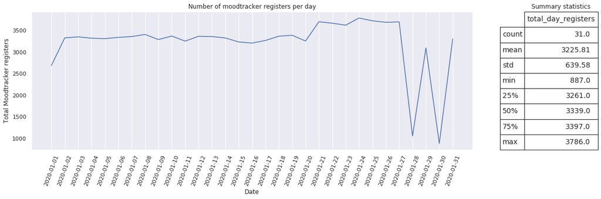

```python
# Let's check how many times the moodtracker feature is used per day per user
moodtracker_df['trackedat_date'] = pd.to_datetime(moodtracker_df.trackedat).strftime('%Y-%m-%d')

# Let's plot the number of moodtracker registers per day
moodtracker_logs_day = moodtracker_df.trackedat_date.value_counts().sort_index().reset_index()
moodtracker_logs_day.columns = ['trackedat_date', 'total_day_registers']

# Let's check some summary statistics on the number of moodtracker registers
f, (ax1, ax2) = plt.subplots(1, 2, gridspec_kw={'width_ratios': [6, 1]}, figsize=(20,5))

chart=sns.lineplot(x='trackedat_date', y='total_day_registers',
                 markers=True,
                 data=moodtracker_logs_day, ax=ax1)

ax1.set_xlabel("Date")
ax1.set_ylabel("Total Moodtracker registers")
ax1.tick_params('x',labelrotation=70)
ax1.set_title("Number of moodtracker registers per day")
chart.yaxis.grid(False)

font_size=14
bbox=[0, 0, 1, 1]
ax2.axis('off')
ax2.set_title("Summary statistics")
mpl_table = ax2.table(cellText = moodtracker_logs_day.describe().round(2).values,
                      rowLabels = moodtracker_logs_day.describe().index,
                      bbox=bbox,
                      colLabels=moodtracker_logs_day.describe().columns)
mpl_table.auto_set_font_size(False)
mpl_table.set_fontsize(font_size)
```

Following this we see a sharp dip on 2020-01-28, followed by a small increase the following day and another dip to the minimum value registered of 887, followed by another increase on the last day of the month.

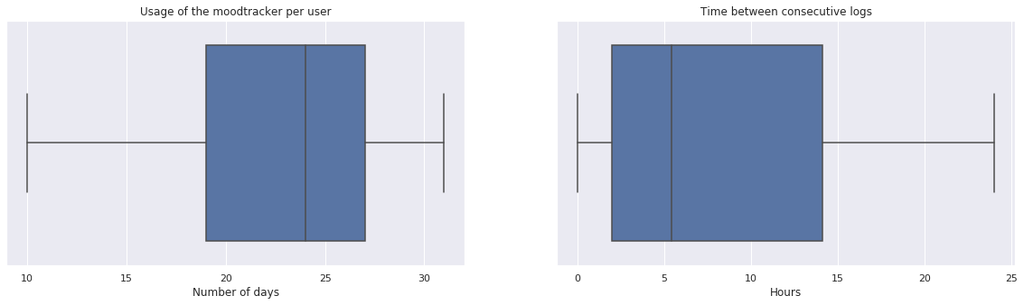

```python
# Let's check how many days each user has on the moodtracker feature as well as the time interval between consecutive logs
user_engagement_df = moodtracker_df.groupby("userid").agg({"trackedat_date":"nunique",
                                     "trackedat": diff_time}).reset_index()

user_engagement_df.rename(columns = {"trackedat_date": "number_of_days",
                                    "trackedat" : 'time_between_logs'}, inplace=True)

# We merge all the time differences in a single series so we can compute summary statistics over all the population
time_between_consecutive_logs = pd.Series(user_engagement_df.time_between_logs.sum())

# The first entry for each user is always NaT, so we can remove that
time_between_consecutive_logs.dropna(inplace=True)

# We convert the time difference to minutes for readability
time_between_consecutive_logs_m = time_between_consecutive_logs.apply(lambda x: x.seconds/60)

# Let's plot both distributions
f, (ax1, ax2) = plt.subplots(1, 2, figsize=(20,5))

sns.boxplot(x=user_engagement_df.number_of_days, ax=ax1)
ax1.set_xlabel("Number of days")
ax1.set_title("Usage of the moodtracker per user")

sns.boxplot(x=time_between_consecutive_logs_m/60, ax=ax2)
ax2.set_xlabel("Hours")
ax2.set_title("Time between consecutive logs")

plt.show()
```

The plots above shows for how long users used the moodtracker feature as well as how frequently they did it.

From the left plot we can see that most of the users used the moodtracker up to 19 to 27 days, with the median at 24 days and the mean close to 23 days. The 27 days limit is a curious one, since it lines up with the day where the big drop in moodtracker logs is registered (2020-01-28).

The right plot shows the time passed in hours between a user's consecutive logs. Here we can already see that there might be an issue on our table, since we have a minimum value of 0 hours, meaning that there are users with more than one log in the same instant of time. This is something we will get back to later.

We can observe with this plot that 50% of the users waits between 2 to 14 hours before returning to use the moodtracker. We can see how this data is affected by the drop in users towards the end of the month by looking at the mean (~8 hours) vs the median (~5 hours). Since the median is more resistent to outlier values, it's expected that if the sudden drops at the end of the month hadn't happened, then these values would be closer, meaning that on average our users wait around 5 hours before using the moodtracker feature again.

### First & Last Seen

Another interesting measure we can take is the number of users first seen on a given day and the number of last seen. This can also show us the first and last mood logged per user.

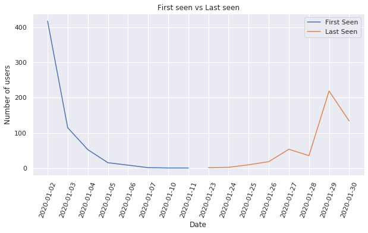

```python
# First seen + Last seen on
first_seen = moodtracker_df.sort_values(["userid", "trackedat"]).drop_duplicates("userid", keep='first')
last_seen = moodtracker_df.sort_values(["userid", "trackedat"]).drop_duplicates("userid", keep='last')

# Plot both curves
fig = plt.figure(figsize=(10,5))
sns.lineplot(x = 'index',
             y = 0,
             data=pd.DataFrame(first_seen.trackedat_date.value_counts()[1:]).reset_index()
            )

sns.lineplot(x = 'index',
             y = 0,
             data=pd.DataFrame(last_seen.trackedat_date.value_counts()[1:]).reset_index()
            )

plt.title("First seen vs Last seen")
plt.xlabel('Date')
plt.ylabel('Number of users')
plt.tick_params('x',labelrotation=70)

plt.legend(('First Seen', 'Last Seen'))
plt.show()
```

To make the plot above, the first and last day of the month were excluded, since we don't have visibility into the periods before and after this month, so we can't make any statement about the number of new/leaving users on those days. This is also relevant when discussing the "Last Seen" curve, since we don't know if users that may have "left" the moodtracker actually used it again on the following month.

Looking at the "First Seen" curve, we see that the amount of new users during the month decreased almost exponentially and from 2020-01-11 forwards, no new user was registered.

Regarding the "Last Seen" curve, we can see that up until 2020-01-23, there were no users stopping the usage of the moodtracker. This value only starts to increase significantly around 2020-01-26. We can see a local maxima at 2020-01-27 and the maximum value at 2020-01-29. These are the days that precede the big drops in the number of moodtracker logs.

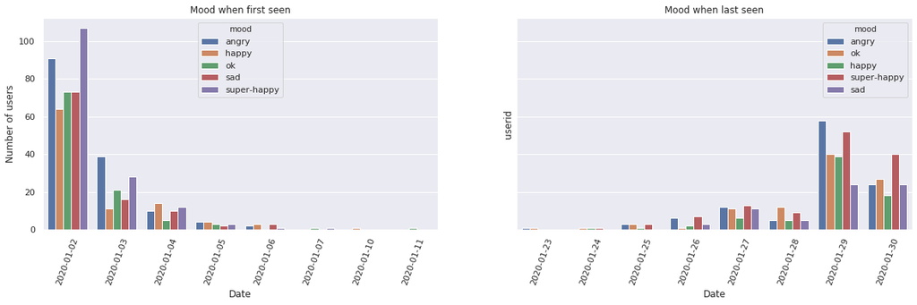

```python
# Let's plot the mood difference from new and leaving users
first_seen_p = first_seen.query("mood != ''").query("trackedat_date != '2020-01-01'").groupby(["trackedat_date", "mood"])["userid"].nunique().reset_index()
last_seen_p = last_seen.query("mood != ''").query("trackedat_date != '2020-01-31'").groupby(["trackedat_date", "mood"])["userid"].nunique().reset_index()

f, (ax1, ax2) = plt.subplots(1, 2, figsize=(20,5), sharey=True)

g=sns.barplot(x='trackedat_date',
           y='userid',
           hue='mood',
           data=first_seen_p,
           ax = ax1)

ax1.set_xlabel("Date")
ax1.set_ylabel("Number of users")
ax1.set_title("Mood when first seen")
ax1.tick_params('x',labelrotation=70)

l=sns.barplot(x='trackedat_date',
           y='userid',
           hue='mood',
           data=last_seen_p,
           ax = ax2)

ax2.set_xlabel("Date")
ax2.set_title("Mood when last seen")
ax2.tick_params('x',labelrotation=70)
plt.show()
```

In the plots above the y axis (Number of users) is share between both plots, to better compare the number of users. Also, just like before, the first and last day of the month were excluded.

We can see on the left-side plot, that most users first show up with a "angry" or "super-happy" mood, but as time goes on, there is more balance on the amount of each mood registered. On the right-side we can see an almost mirror progression, as the number of users "leaving" increases, so does the difference between the mood categories.

### Daily Activity

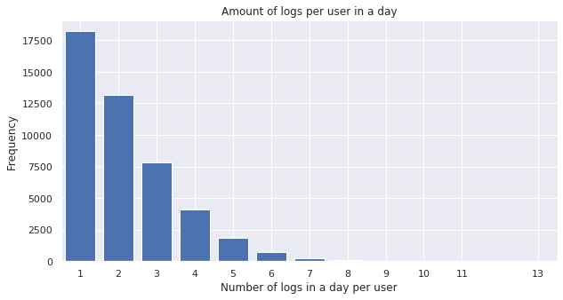

```
There are a total of 99996 logs.
The probability of a user using the tracker 5 or more times is 6.14%
```

```python
# Let's compute how many mood values each user registers per day
daily_mood_user = moodtracker_df.groupby(["trackedat_date", "userid"]).agg({"trackedat" : "nunique",
                                                          "mood": ["unique", 'nunique'],
                                                         })
# Flatten multiindex table
daily_mood_user = daily_mood_user.stack().reset_index().rename(columns = {"level_2":"applied_function"}).copy()

# Count the number of distinct
daily_mood_user_count = daily_mood_user.query("applied_function == 'nunique'").trackedat.value_counts().reset_index().copy()
daily_mood_user_count.columns = ["number_of_registers", "count"]

# Plot the frequency of the amount of logs per user daily
x = daily_mood_user_count["number_of_registers"]
height = daily_mood_user_count["count"]

fig = plt.figure(figsize=(10,5))
_ = plt.bar(x=x,
        height=height)

plt.xlim([x.min()-0.5,x.max()+0.5])
plt.title("Amount of logs per user in a day")
plt.xlabel("Number of logs in a day per user")
plt.ylabel("Frequency")
plt.xticks(x)
plt.show()

# Total of logs that were logged in a batch < 4 per day
sum((daily_mood_user_count["count"]*daily_mood_user_count["number_of_registers"]/99996*100)[0:3])

total_logs = round(sum(daily_mood_user_count["count"]*daily_mood_user_count["number_of_registers"]))
print(f'There are a total of {str(total_logs)} logs.')

prob_more_than5 = round(sum(daily_mood_user_count["count"][4:])/sum(daily_mood_user_count["count"])*100,2)
print(f"The probability of a user using the tracker 5 or more times is {prob_more_than5}%")
```

Like shown in the plot above, usually the vast majority of users tend to use the moodtracker between 1 to 3 times per day (this group represent around 68% of the registers in the table). We also see that there is a very low probability of a user using the moodtracker 5 or more times in the same day.

This plot raises 2 questions though:

- The total of logs computed from the plot is 99996 logs instead of the original 100000. What happened to the missing 4?
- This plot does not show the amount of different moods logged throughout the day. What if a user logs more than 1 mood per day?

```python
# Since we grouped the data by userid and date and counted the distinct timestamps to get the number of logs
# we should check if there are duplicate pair of userid/trackedat timestamps

print(f'There are {sum(moodtracker_df.duplicated(["userid", "trackedat"]))} duplicate userid/timestamp pairs.')
print("Duplicate entries:")
display(moodtracker_df[moodtracker_df.duplicated(["userid", "trackedat"], keep = False)].sort_values("trackedat"))
```

```
There are 4 duplicate userid/timestamp pairs.
Duplicate entries:
```

|  | id | userid | trackedat | mood | reasonid | trackedat_date |
| --- | --- | --- | --- | --- | --- | --- |
| 18911 | 1c694811-e7fb-4fb4-80f0-ee8ec095d19a | 5503d473-aa7c-47fa-93ae-e000d54d2531 | 2020-01-02 18:52:29 | angry | 58335abb514129a045865b08 | 2020-01-02 |
| 61396 | 824d5ca9-5fad-44e6-a907-be2515df0766 | 5503d473-aa7c-47fa-93ae-e000d54d2531 | 2020-01-02 18:52:29 | happy | 5c6c293f9c79eca733d4dd0b | 2020-01-02 |
| 16280 | 26e281f2-092d-45e6-839d-875d1716e4cf | 833800cf-b9d2-4e95-89db-5a1d17c97dc7 | 2020-01-10 18:51:52 | angry | 5c6c2a259c79eca733d4dd1b | 2020-01-10 |
| 27059 | 64bbf981-f851-412c-9942-e76d5ab77e40 | 833800cf-b9d2-4e95-89db-5a1d17c97dc7 | 2020-01-10 18:51:52 | ok | 57d9dc1ee66d040ed4e496a9 | 2020-01-10 |
| 55622 | d51138fc-8c8e-4a38-b2bc-db89a2da8bf9 | a7ccfd35-58fa-484e-aeee-f1d9e6167d6e | 2020-01-10 22:14:49 | super-happy | 57d9dc1de66d040ed4e4969e | 2020-01-10 |
| 78862 | f153221c-b54f-4eef-ad91-d60ce7f49f1f | a7ccfd35-58fa-484e-aeee-f1d9e6167d6e | 2020-01-10 22:14:49 | super-happy | 5b0d5ce1abb35bed38c2ce52 | 2020-01-10 |
| 18418 | 6c56ea16-a95f-45c5-ae8f-4e8c856efc86 | 14050378-d393-4821-9291-cce422f981e6 | 2020-01-21 18:13:41 | super-happy | 57d9dc1de66d040ed4e4969e | 2020-01-21 |
| 43383 | 71b1a22c-c51a-4659-ad4a-f46f6b44f3a3 | 14050378-d393-4821-9291-cce422f981e6 | 2020-01-21 18:13:41 | happy | 58335abb514129a045865b08 | 2020-01-21 |

We now know where the 4 missing entries are. We can see that there are entries with the same userid and timestamp, but with they are either duplicates or have different moods. Since there are only 4 instances of this out of 100k rows in the table, we are not fixing it for the scope of this report.

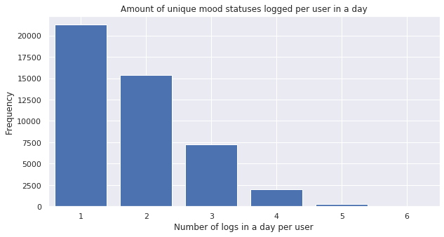

```
There are a total of 82994 logs.
The probability of a user registering 3 or more distinct moods is 20.65%
```

```python
# Count the number of distinct
daily_mood_mood_count = daily_mood_user.query("applied_function == 'nunique'").mood.value_counts().reset_index().copy()
daily_mood_mood_count.columns = ["number_of_mood", "count"]

# Plot the frequency of the amount of logs per user daily
x = daily_mood_mood_count["number_of_mood"]
height = daily_mood_mood_count["count"]

fig = plt.figure(figsize=(10,5))
_ = plt.bar(x=x,
        height= height)

plt.xlim([x.min()-0.5,x.max()+0.5])
plt.title("Amount of unique mood statuses logged per user in a day")
plt.xlabel("Number of logs in a day per user")
plt.ylabel("Frequency")
plt.xticks(x)
plt.show()

# Total of logs that were logged in a batch < 4 per day
sum((daily_mood_mood_count["count"]*daily_mood_mood_count["number_of_mood"]/99996*100)[0:3])

total_logs = round(sum(daily_mood_mood_count["count"]*daily_mood_mood_count["number_of_mood"]))
print(f'There are a total of {str(total_logs)} logs.')

prob_more_than = round(sum(daily_mood_mood_count["count"][2:])/sum(daily_mood_mood_count["count"])*100,2)
print(f"The probability of a user registering 3 or more distinct moods is {prob_more_than}%")
```

Like before, we have inconsistent number of logs, 82994 vs 100000. We aggregated our data by userid and date. If in the same day, the same user logged the same mood more than once, we are only counting it once (hence the importance of being explicit about **distinct** mood values).

```python
# Let's check for duplicated moods logged in the same day
print(f'There are {sum(moodtracker_df.duplicated(["userid", "trackedat_date", "mood"]))} duplicate userid/date/mood tuples.')
```

```
There are 17006 duplicate userid/date/mood tuples.
```

Now that we have some insights regarding the use of the moodtracker, we can start to think about how to connect the information on `moodtracker_df` with the one of the population.

## Emotional State Analysis

Our target variable is **mood**. This is a categorical variable, meaning that we can't simply compute it's average value for each day, since all we have are strings.

- Since we have some insight on the moodtracker data, we can transform our table to make our life easier while still using the data correctly. Here's what we know:
  - Most users don't use the moodtracker feature more than 2~3 times per day.
  - 80% of the users log either 1 or 2 distinct moods in a day.
  - A user can log the same mood more than once in a day.
- With these informations in mind, we're going to edit our moodtracker table so that we only have 1 mood value per user per day. The steps to do this are:
  - Take the most frequent mood for each user, each day.
  - If there is no clear value that is more frequent than the others, take the last one registered.
- This analysis will be biased towards the mood of people at the end of the day.

```python
# Create a copy of the original dataframe for transformation
c_moodtracker_df = moodtracker_df.copy()

# We sort the dataframe here to be easier to take the last value if no mode exists
c_moodtracker_df.sort_values(["userid", "trackedat"], inplace=True)

# Aggregate with the custom get_mode function
c_moodtracker_df = c_moodtracker_df.groupby(["userid", "trackedat_date"]).agg({"mood" : get_mode}).reset_index()
```

### General Population

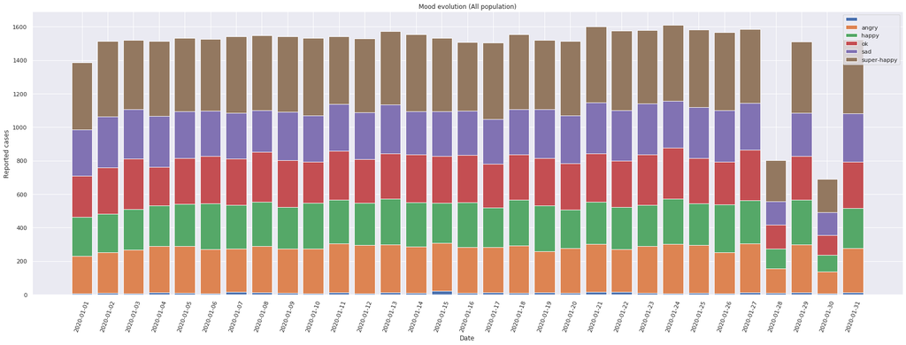

```python
# Plot mood evolution for entire population
mood_evolution(c_moodtracker_df)
```

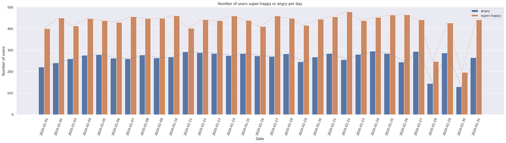

```python
# Plot extreme moods comparison
mood_comparison(c_moodtracker_df, 'angry', 'super-happy')
```

We can see that the number of users that keep either mood status from one day to another is stable. An increase in either mood does not reflect in a decrease in the opposite one, as noted previously. Like mentioned before, the drop in the final days of the month are proportional for these moods.

Now that we've seen the picture for the total population, we can drill down on different subsets. For that we will finally integrate the `pop_df` table. We are going to look into the following subsets:

- All users that work in each industry
- All users that work in each company
- All users of a given (guessed) gender - only considering male or female here
- All users of a given age range - 3 groups: <= 21 years old | > 21 & < 32 years old | >= 32 years old (these groups were decided based on the quantiles of the age of the total users)

The results will be discussed at the end.

Note: Since the '' (`unknown`) mood does not add a lot of information when we reduce our population size, so for these subset analysis we are going to discard those entries.

```python
# We're going to join our transformed moodtracker table with pop_df
# but first we remove all unknown moods
s_moodtracker_df = c_moodtracker_df.query("mood !=''").copy()
```

### Per Industry

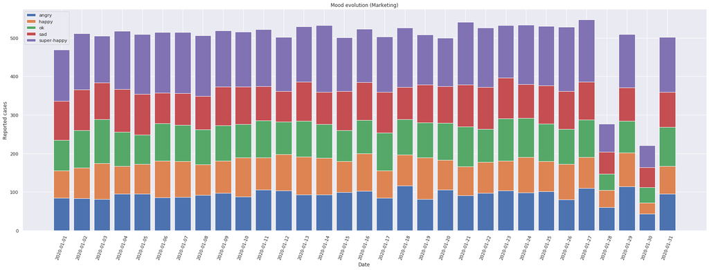

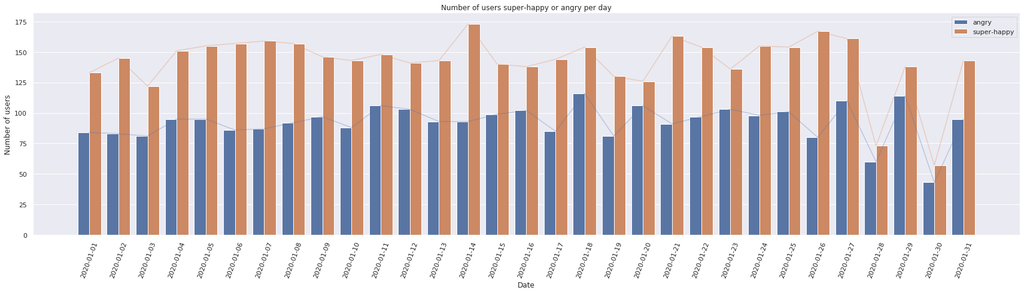

```
The overall percentage for each mood is:
```

```
super-happy    28.47
sad            18.69
angry          18.51
ok             17.92
happy          16.41
dtype: float64
```

```python
# Start with the marketing industry
s_df = s_moodtracker_df.merge(pop_df.query("industryname=='Marketing'")[["userid"]], how = 'inner', on='userid')
mood_evolution(s_df, 'Marketing')

# Plot extreme moods comparison
mood_comparison(s_df, 'angry', 'super-happy')

# Print "mood percentage"
print("The overall percentage for each mood is:")
display(round(s_df.mood.value_counts(normalize=True)*100, 2))
```

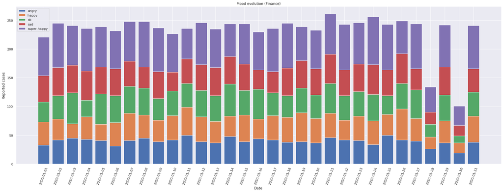

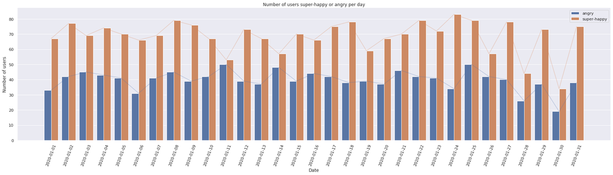

```
The overall percentage for each mood is:
```

```
super-happy    29.40
sad            18.72
ok             18.15
angry          17.03
happy          16.70
dtype: float64
```

```python
# Finance
s_df = s_moodtracker_df.merge(pop_df.query("industryname=='Finance'")[["userid"]], how = 'inner', on='userid')
mood_evolution(s_df, 'Finance')

# Plot extreme moods comparison
mood_comparison(s_df, 'angry', 'super-happy')

# Print "mood percentage"
print("The overall percentage for each mood is:")
display(round(s_df.mood.value_counts(normalize=True)*100, 2))
```

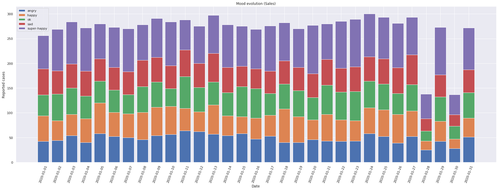

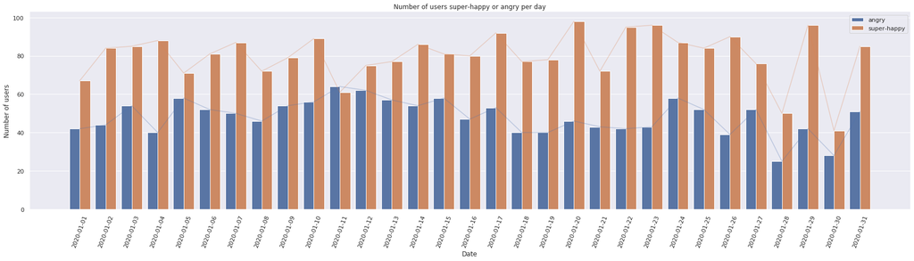

```
The overall percentage for each mood is:
```

```
super-happy    29.58
ok             17.92
angry          17.79
sad            17.48
happy          17.22
dtype: float64
```

```python
# Sales
s_df = s_moodtracker_df.merge(pop_df.query("industryname=='Sales'")[["userid"]], how = 'inner', on='userid')
mood_evolution(s_df, 'Sales')

# Plot extreme moods comparison
mood_comparison(s_df, 'angry', 'super-happy')

# Print "mood percentage"
print("The overall percentage for each mood is:")
display(round(s_df.mood.value_counts(normalize=True)*100, 2))
```

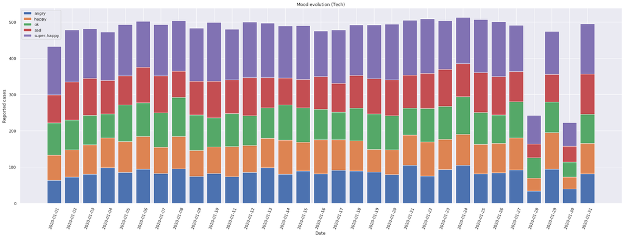

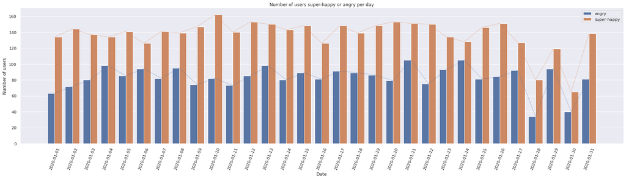

```
The overall percentage for each mood is:
```

```
super-happy    28.86
sad            18.81
ok             18.28
angry          17.42
happy          16.63
dtype: float64
```

```python
# Tech
s_df = s_moodtracker_df.merge(pop_df.query("industryname=='Tech'")[["userid"]], how = 'inner', on='userid')
mood_evolution(s_df, 'Tech')

# Plot extreme moods comparison
mood_comparison(s_df, 'angry', 'super-happy')

# Print "mood percentage"
print("The overall percentage for each mood is:")
display(round(s_df.mood.value_counts(normalize=True)*100, 2))
```

In this section we can see that:

### Per Company

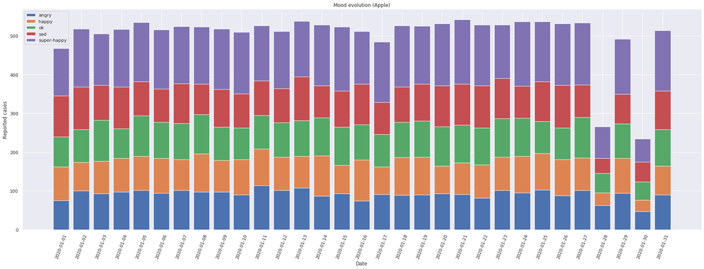

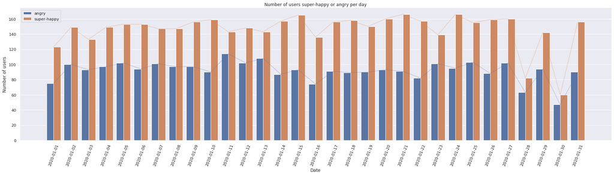

```
The overall percentage for each mood is:
```

```
super-happy    29.03
sad            18.36
angry          18.23
ok             17.81
happy          16.57
dtype: float64
```

```python
# Apple
s_df = s_moodtracker_df.merge(pop_df.query("companyname=='Apple'")[["userid"]], how = 'inner', on='userid')
mood_evolution(s_df, 'Apple')

# Plot extreme moods comparison
mood_comparison(s_df, 'angry', 'super-happy')

# Print "mood percentage"
print("The overall percentage for each mood is:")
display(round(s_df.mood.value_counts(normalize=True)*100, 2))
```

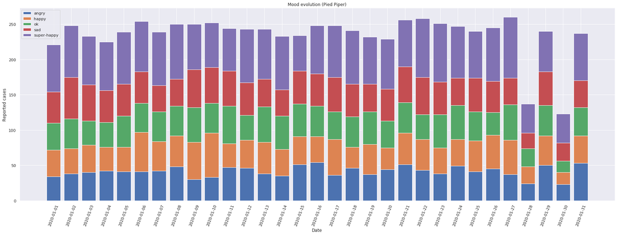

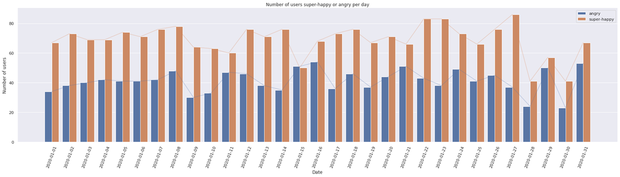

```
The overall percentage for each mood is:
```

```
super-happy    29.19
sad            18.71
angry          17.49
ok             17.40
happy          17.21
dtype: float64
```

```python
# Pied Piper
s_df = s_moodtracker_df.merge(pop_df.query("companyname=='Pied Piper'")[["userid"]], how = 'inner', on='userid')
mood_evolution(s_df, 'Pied Piper')

# Plot extreme moods comparison
mood_comparison(s_df, 'angry', 'super-happy')

# Print "mood percentage"
print("The overall percentage for each mood is:")
display(round(s_df.mood.value_counts(normalize=True)*100, 2))
```

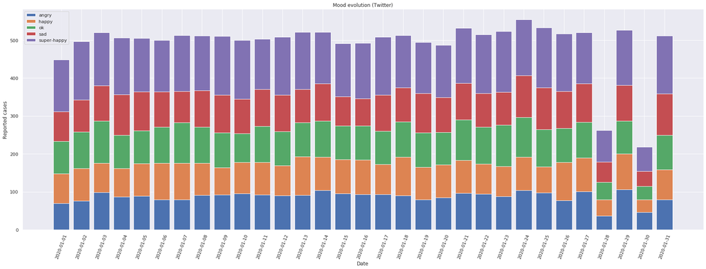

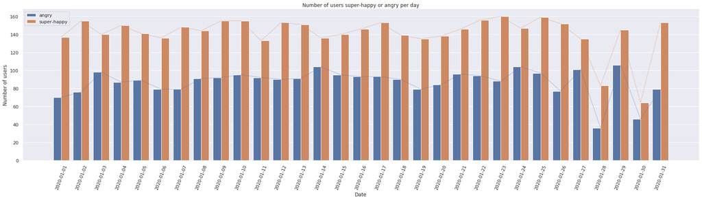

```
The overall percentage for each mood is:
```

```
super-happy    28.74
sad            18.48
ok             18.34
angry          17.64
happy          16.80
dtype: float64
```

```python
# Twitter
s_df = s_moodtracker_df.merge(pop_df.query("companyname=='Twitter'")[["userid"]], how = 'inner', on='userid')
mood_evolution(s_df, 'Twitter')

# Plot extreme moods comparison
mood_comparison(s_df, 'angry', 'super-happy')

# Print "mood percentage"
print("The overall percentage for each mood is:")
display(round(s_df.mood.value_counts(normalize=True)*100, 2))
```

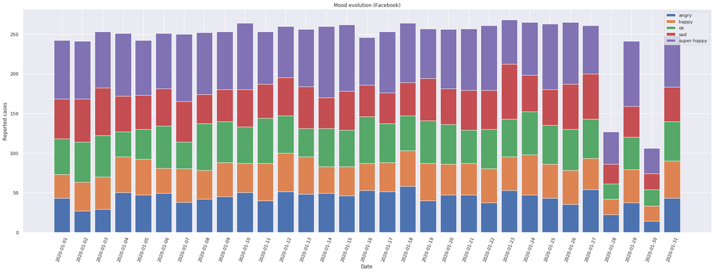

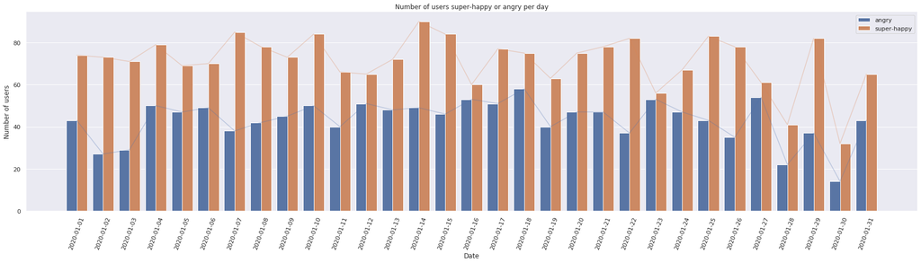

```
The overall percentage for each mood is:
```

```
super-happy    28.95
ok             18.72
sad            18.68
angry          17.50
happy          16.15
dtype: float64
```

```python
# Facebook
s_df = s_moodtracker_df.merge(pop_df.query("companyname=='Facebook'")[["userid"]], how = 'inner', on='userid')
mood_evolution(s_df, 'Facebook')

# Plot extreme moods comparison
mood_comparison(s_df, 'angry', 'super-happy')

# Print "mood percentage"
print("The overall percentage for each mood is:")
display(round(s_df.mood.value_counts(normalize=True)*100, 2))
```

Regarding the companies, we have a mix of all the industries, however it is still interesting to compare these:

- Apple
  - Very similar to the general population plots.
- Pied Piper
  - This company has the most balanced mood distribution, while at the same time having the highest relative percentage of 'super-happy' customers.
  - The "extreme" mood plot has the most noticeable variation among all companies.
- Twitter
  - Very similar to the general population plots.
- Facebook
  - The mood "ok" is more prevalent here than in other companies.
  - The 3 middle ranked moods ("ok", "sad" and "angry") are ranked in a totally different order from the remaining company.
  - This company has the least amount of "happy" employees.
  - There is a increase in the number of super-happy employees betwwen 2020-01-23 and 2020-01-26 that coincides with a decrease in angry, so this could be indicative of something that happened in the company.

### Per (Guessed) Gender

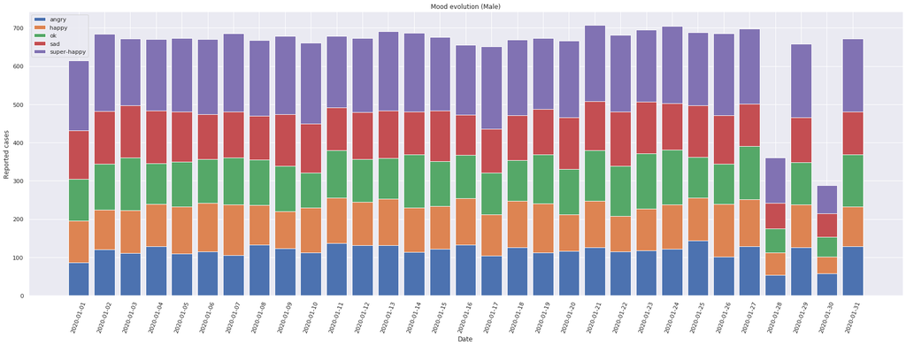

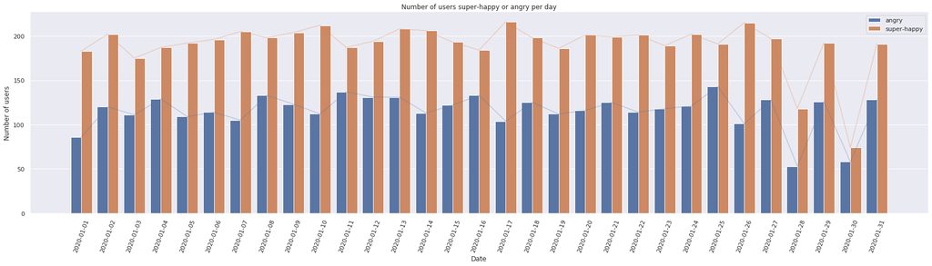

```
The overall percentage for each mood is:
```

```
super-happy    29.14
sad            18.47
ok             17.79
angry          17.70
happy          16.91
dtype: float64
```

```python
# Male
s_df = s_moodtracker_df.merge(pop_df.query("genderguess=='male'")[["userid"]], how = 'inner', on='userid')
mood_evolution(s_df, 'Male')

# Plot extreme moods comparison
mood_comparison(s_df, 'angry', 'super-happy')

# Print "mood percentage"
print("The overall percentage for each mood is:")
display(round(s_df.mood.value_counts(normalize=True)*100, 2))
```

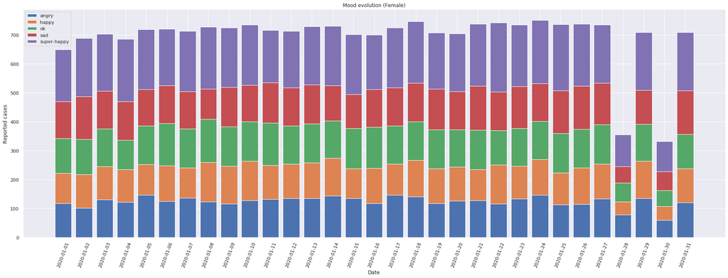

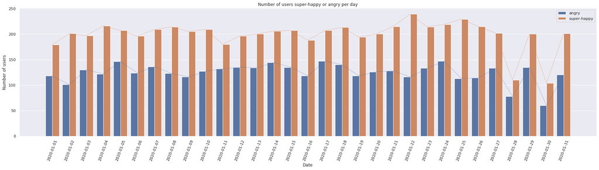

```
The overall percentage for each mood is:
```

```
super-happy    28.70
sad            18.58
ok             18.36
angry          17.90
happy          16.47
dtype: float64
```

```python
# Female
s_df = s_moodtracker_df.merge(pop_df.query("genderguess=='female'")[["userid"]], how = 'inner', on='userid')
mood_evolution(s_df, 'Female')

# Plot extreme moods comparison
mood_comparison(s_df, 'angry', 'super-happy')

# Print "mood percentage"
print("The overall percentage for each mood is:")
display(round(s_df.mood.value_counts(normalize=True)*100, 2))
```